# Central Electric Power Cooperative Network

Tyler Jackson

Katelin Jones

UC Davis Community Economic Development Lab

## Interactive Maps

### Central Electric Power Cooperative Network

This map presents a starting point for exploring Central Electric’s network. It is an interactive view of each node that we have identified as part of the larger cooperative network.

[interactive chart not shown]

## Network Graphs

### The Whole Network

This graph represents the South Carolina Electric Cooperative Network. Through various methods of data collection we have identified 73 nodes inside and outside of South Carolina that represent different types of business and development. Those nodes have been colored by category. The things seen toward the center of the graph have a high amount of connections, that is, they are central to the network, while those found toward the outside of graph have low connections, meaning they are close to being independent of the network. For further exploration, we’ll look at the network in a few different ways.

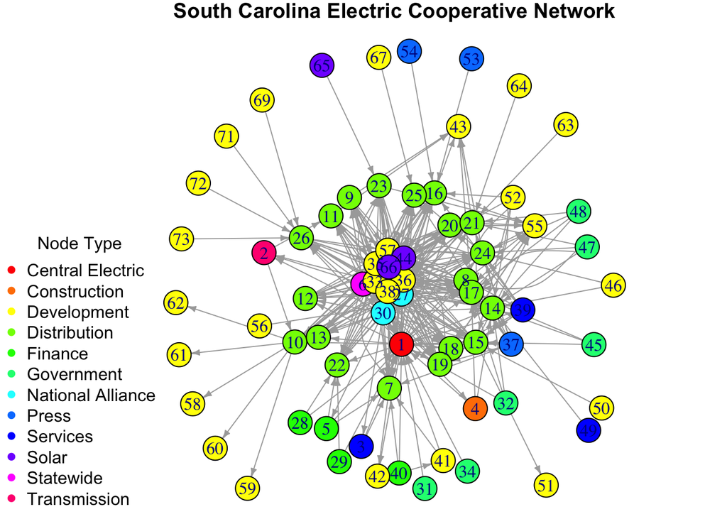

### Central Electric Power Cooperative

The graph below shows Central’s immediate network. That means that we are seeing nodes that are only one level away from Central. As with the first graph, centrality equals highly connected. It’s easy to see the ring of distribution cooperatives in green in this graph. Of note is the reduction of most of nodes in the “Development” category in this graph.

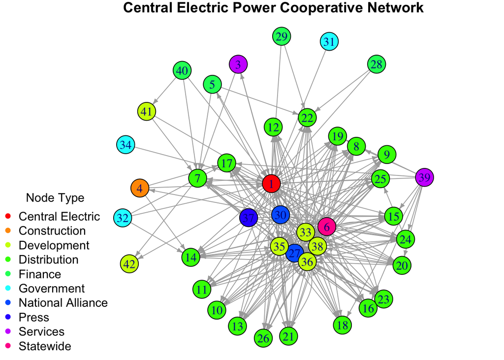

### Distribution Cooperatives

The graph below shows all nodes within one level of a distribution cooperative. This shows more of the nodes associated with individual cooperatives rather than directly connected to Central. Notice that most of these nodes are of the “Development” type.

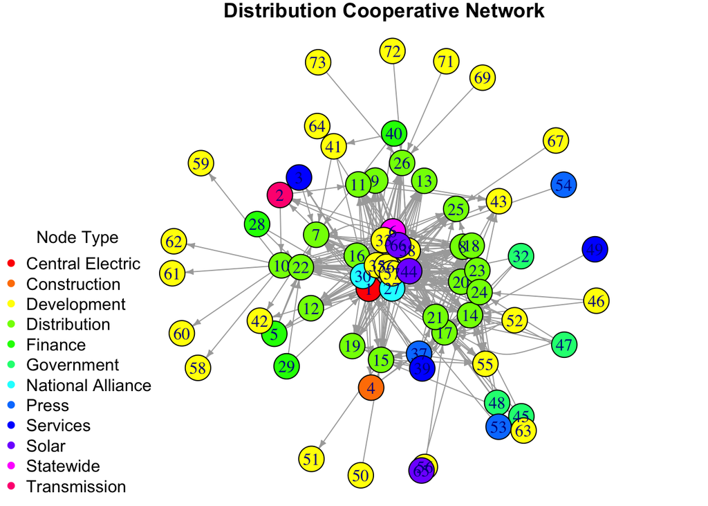

### Santee

In this graph, we see one individual distribution cooperative, Santee. It’s interesting to note the types of nodes connected directly to Santee (26) and connected through Central (1). It looks like development programs are happening both at the distribution level as well as through Central.

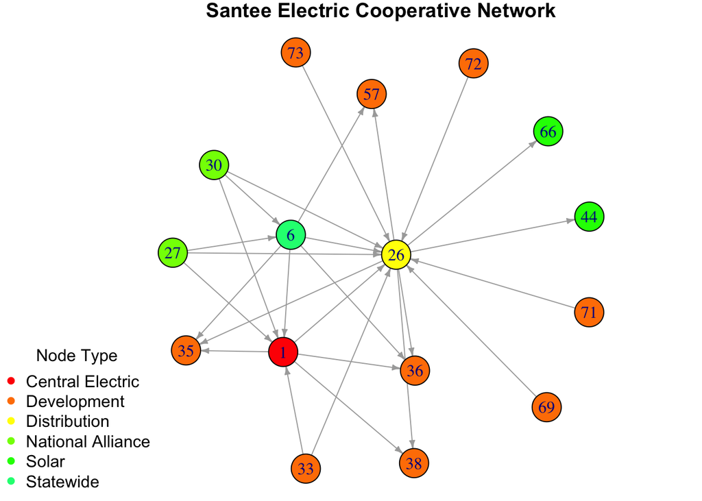

### Spatial Network

Below, we see that the network can also be visualized spatially, that is, we can map it! This might be useful when thinking about how programs might be able to link together by location. If one node is close to another node but they aren’t connected, we can ask, why not? This can provide more insight about how to work for even better cooperation.

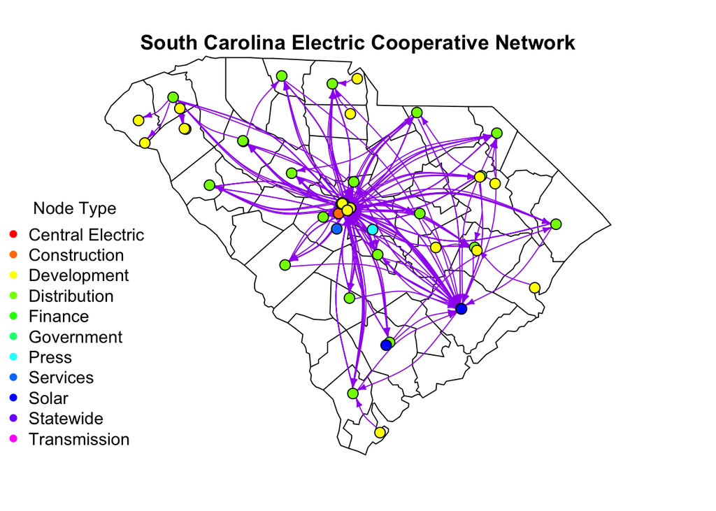